# Red Wine Quality Data Analysis by Paul Hsiao

### density vs quality

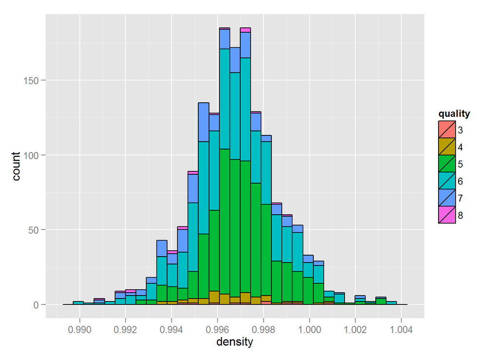

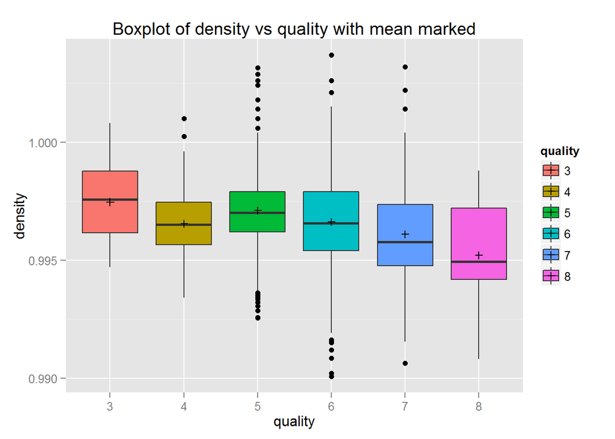

```
## Source: local data frame [6 x 6]
##
##   quality     Min   Median      Mean     Max   n
## 1       3 0.99471 0.997565 0.9974640 1.00080  10
## 2       4 0.99340 0.996500 0.9965425 1.00100  53
## 3       5 0.99256 0.997000 0.9971036 1.00315 681
## 4       6 0.99007 0.996560 0.9966151 1.00369 638
## 5       7 0.99064 0.995770 0.9961043 1.00320 199
## 6       8 0.99080 0.994940 0.9952122 0.99880  18
```

Correlation between density and quality is **-0.1749192**

Here we observe that higher quality wines tend to have lower density median value.

### chlorides vs quality

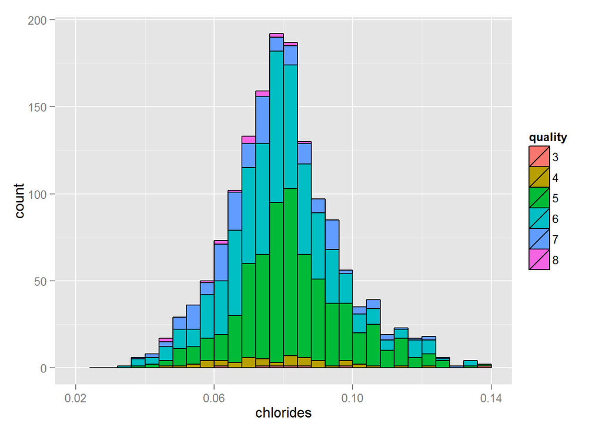

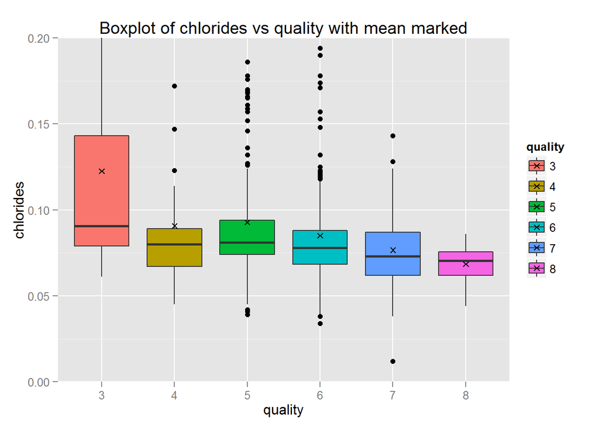

```
## Source: local data frame [6 x 6]
##
##   quality   Min Median       Mean   Max   n
## 1       3 0.061 0.0905 0.12250000 0.267  10
## 2       4 0.045 0.0800 0.09067925 0.610  53
## 3       5 0.039 0.0810 0.09273568 0.611 681
## 4       6 0.034 0.0780 0.08495611 0.415 638
## 5       7 0.012 0.0730 0.07658794 0.358 199
## 6       8 0.044 0.0705 0.06844444 0.086  18
```

It is quite obvious, higher quality wines tend to have lower chlorides. Chlorides are from salt which is related to environment. I believe it is a fair assumption that wine ingredients (such as grape, water) from more pristine environment tend to have less salt. Thus the wine region producing higher quality wines tend to have better environment.

### total.sulfur.dioxide vs quality

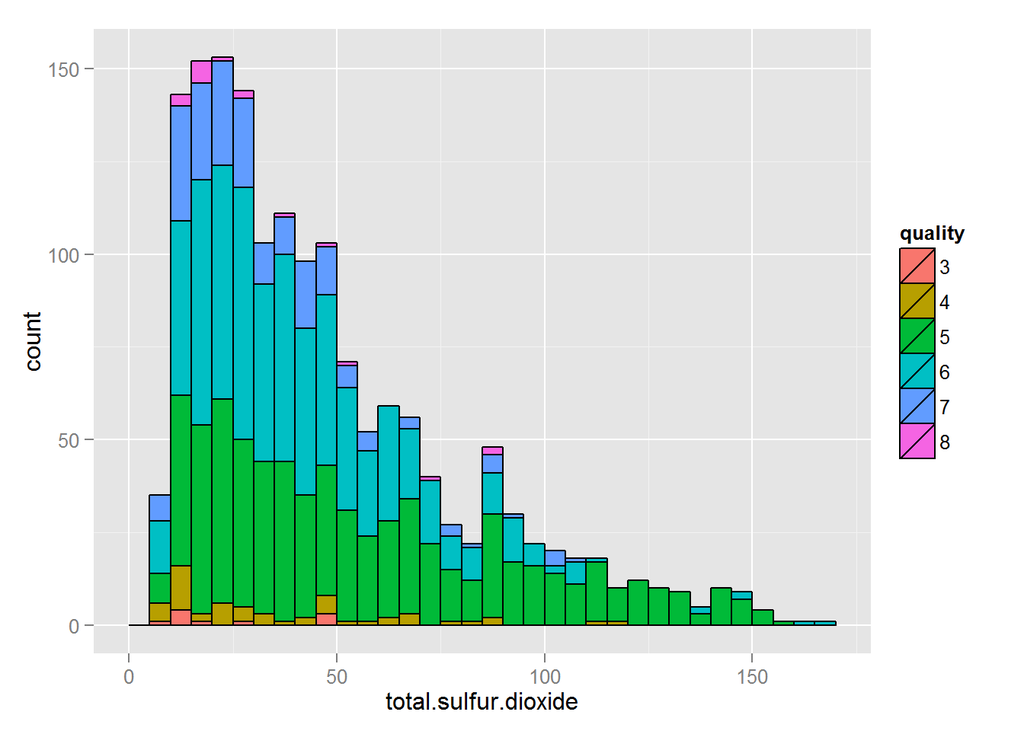

[figure not shown]

```
## Source: local data frame [6 x 6]
##
##   quality Min Median     Mean Max   n
## 1       3   9   15.0 24.90000  49  10
## 2       4   7   26.0 36.24528 119  53
## 3       5   6   47.0 56.51395 155 681
## 4       6   6   35.0 40.86991 165 638
## 5       7   7   27.0 35.02010 289 199
## 6       8  12   21.5 33.44444  88  18
```

Correlation between total.sulfur.dioxide and quality is **-0.1851003**

Earlier I mentioned I want to find out what quality of wines having the max total.sulfur.dioxide value. Here we can see from the statistics by quality that the max value 289 of total.sulfur.dioxide happens for quality 7. From the boxplot, it is very obvious this 289 is an outlier. We can see most quality of wines tend to have lower value of total.sulfur.dioxide. However, the the lowest quality wines have the lowest median total.sulfur.dioxide value.

## Check correlation using scatterplots

Next, lets have a look of correlation between certain features. The features I’ll explore are  
1. fixed.acidity vs pH  
2. fixed.acidity vs density  
3. alcohol vs residual.sugar

In each plot, subset of 99% quantile of each feature is taken to exclude the 1% outliers. However, full data set is used to calculate the correlation.

### fixed.acidity vs pH

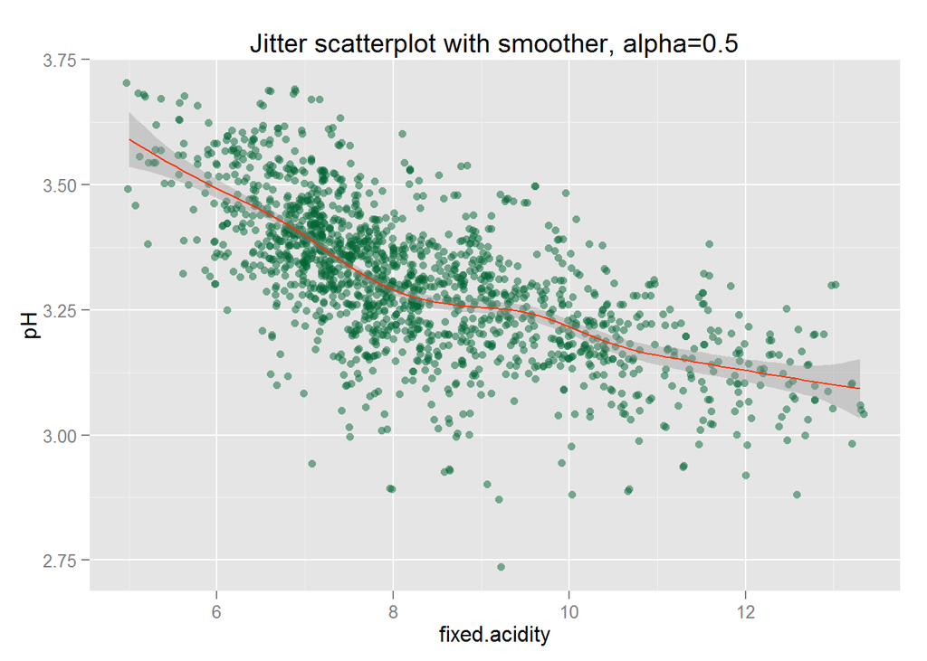

The correlation between fixed.acidity and pH: **-0.6829782**

This plot clearly shows the fixed.acidity has a negative correlation with pH.

### fixed.acidity vs density

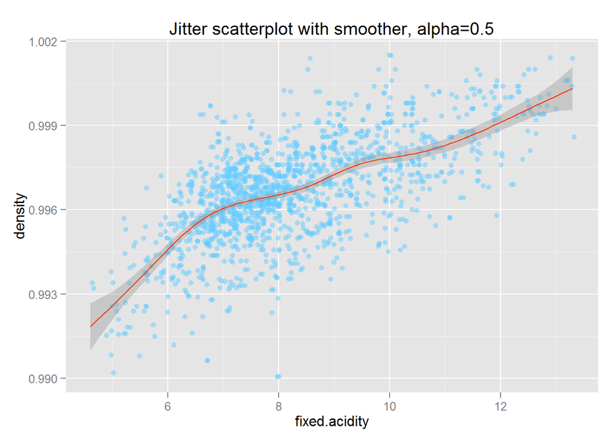

The correlation between fixed.acidity and density: **0.6680473**

This plot shows a positive correlation between fixed.acidity and density.

### alcohol vs residual.sugar

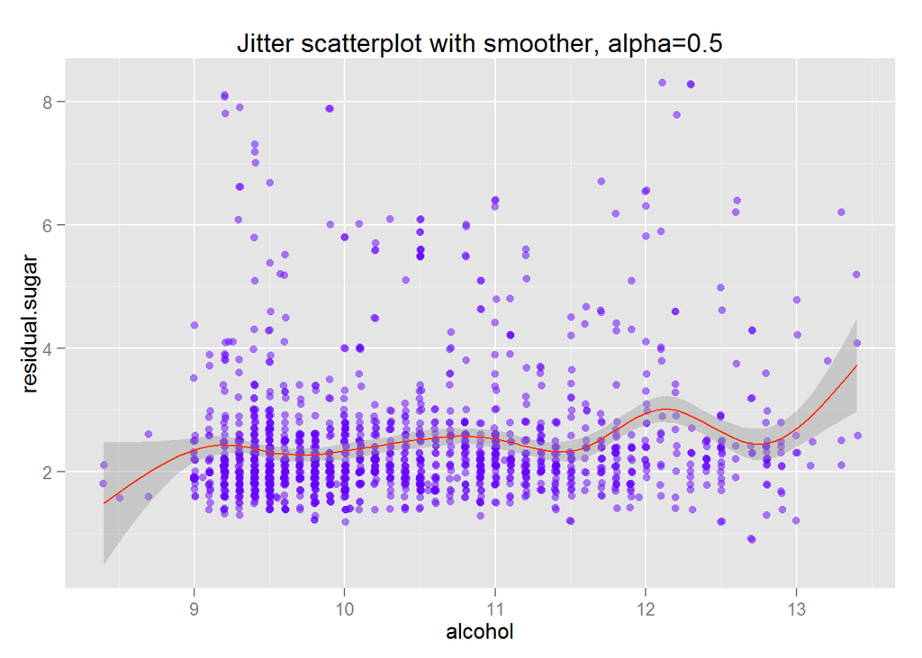

The correlation between alcohol and residual.sugar: **0.0420754**.

This plot shows low correlation between alcohol and residual.sugar. After fermentation process, most of sugar has been transformed into alcohol. Wine makers have tried to control the residual sugar level to adjust the sweet taste of wine.

These scatterplots with smoother have reinforce the earlier observations from Scatterplot Matrices. The correlation between alcohol vs residual.sugar is low, while it is high for the other pairs of features.

Based on the above observations, it is observed for the quality 8 wines:

1. Low pH value (median: 3.23)
2. Low residual sugar (median: 2.1)
3. High alcohol (median: 12.15)
4. Low chlorides (median: 0.0705)
5. Low density (median: 0.994940)
6. Low total.sulfur.dioxide (median: 21.5)

# Bivariate Analysis

### Talk about some of the relationships you observed in this part of the investigation. How did the feature(s) of interest vary with other features in the dataset?

From the Scatterplot matrices, the following are observed:

1. fixed.acidity and density have positive Correlation Coefficient of 0.668.
2. fixed.acidity and pH have negative Correlation Coefficient -0.683. This is expected as higher acidity will decrease the pH value.
3. The rest of the correlations are weak. None of the features has high correlation with quality directly.
4. The scatterplots with smoother have reinforced the above observations.

### Did you observe any interesting relationships between the other features (not the main feature(s) of interest)?

free.sulfur.dioxide and total.sulfur.dioxide have a positive Correlation Coefficient of 0.668. However, this is not a surprise as free.sulfur.dioxide is included in total.sulfur.dioxide.

### What was the strongest relationship you found?

fixed.acidity and pH have the highest Correlation Coefficient -0.683. Wine makers can adjust the pH level, ie. fixed acidity level, so their wine can satisfy consumer’s taste. In this dataset, the median pH level is 3.310.

# Multivariate Plots Section

## 1. pH vs median alcohol per quality

First, lets have a look of pH vs median alcohol per quality.

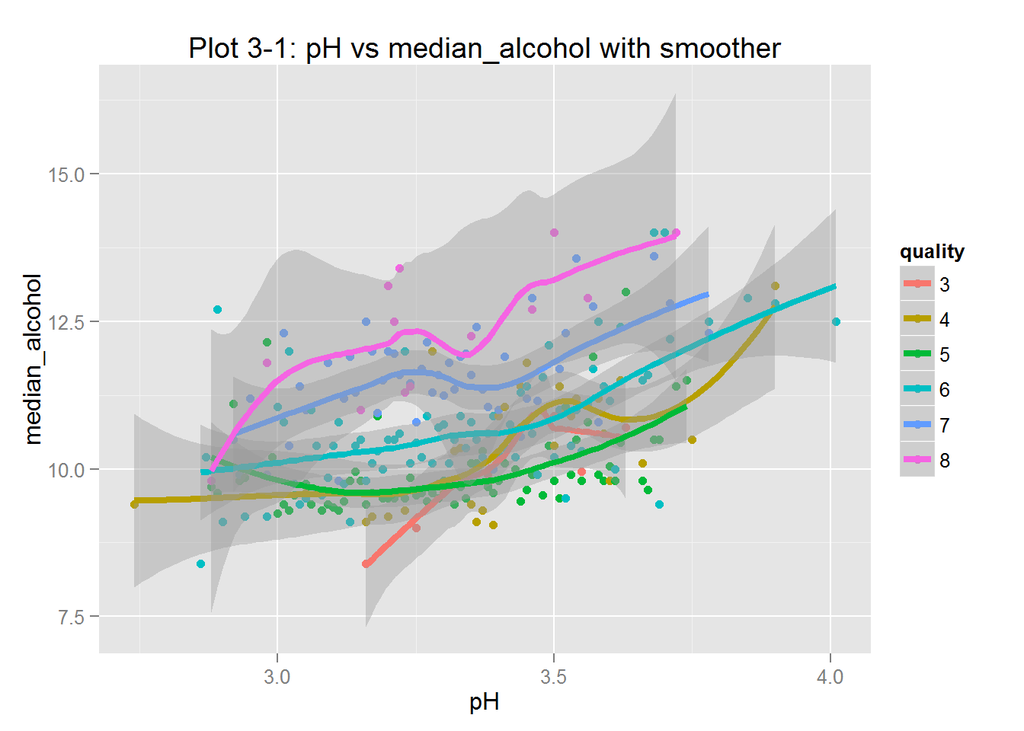

We can see the correlation between pH and median_alcohol per quality in table below are quite high.

The correlation between pH and median_alcohol per quality -

| quality | Correlation between pH and median_alcohol per quality |
| --- | --- |
| 3 | 0.8501442 |
| 4 | 0.5897489 |
| 5 | 0.3716999 |
| 6 | 0.5972137 |
| 7 | 0.4959361 |
| 8 | 0.7654621 |

This plot shows the pH has a positive correlation with median alcohol value for each quality. For higher quality wines, the median alcohol tends to have higher value for the same pH value. This plot gives details into each quality. The following plot shows the smooth trend across all qualities of wine.

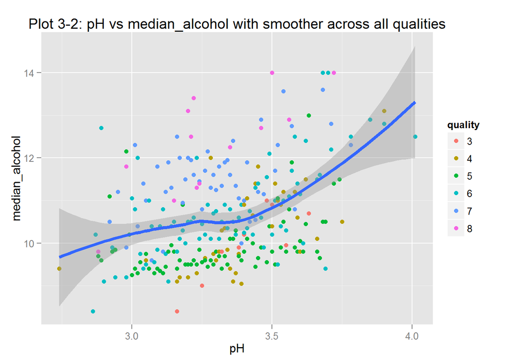

## 2. alcohol vs density per pH bucket

Next, lets look at the alcohol vs density per pH bucket.

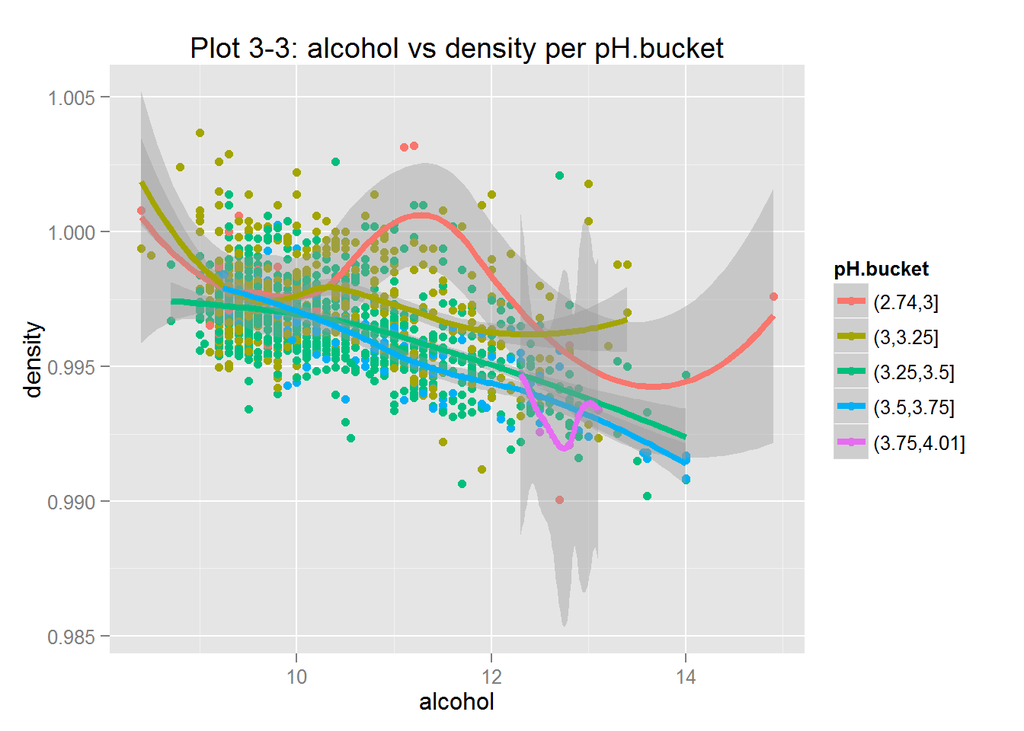

The correlation between alcohol and density: **-0.4961798**.

```
## Source: local data frame [5 x 6]
##
##     pH.bucket     Min  Median      Mean     Max   n
## 1    (2.74,3] 0.99007 0.99760 0.9978503 1.00320  34
## 2    (3,3.25] 0.99120 0.99733 0.9974518 1.00369 515
## 3  (3.25,3.5] 0.99020 0.99647 0.9964985 1.00260 881
## 4  (3.5,3.75] 0.99084 0.99588 0.9957486 1.00025 161
## 5 (3.75,4.01] 0.99210 0.99320 0.9932871 0.99471   7
```

And here is the distribution of alcohol per pH.bucket:

```
## Source: local data frame [5 x 6]
##
##     pH.bucket       Min Median     Mean  Max   n
## 1    (2.74,3]  8.400000   9.85 10.27647 14.9  34
## 2    (3,3.25]  8.400000  10.00 10.26667 13.4 515
## 3  (3.25,3.5]  8.700000  10.20 10.40904 14.0 881
## 4  (3.5,3.75]  9.233333  10.80 10.93944 14.0 161
## 5 (3.75,4.01] 12.300000  12.50 12.65714 13.1   7
```

Now, I’ll show the plot with top 1% alcohol and density removed from the dataset, plus jitter and alpha=0.5.

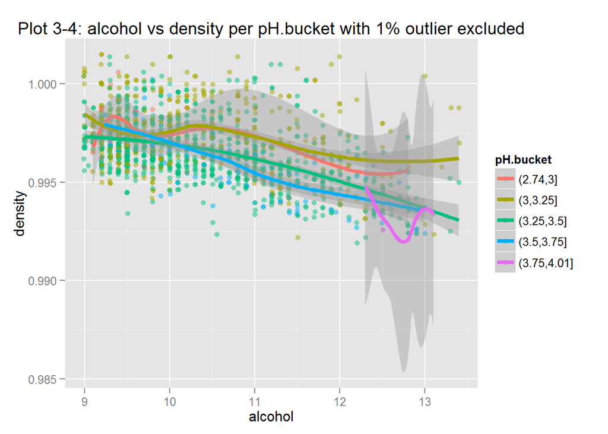

The correlation between alcohol and density per pH.bucket -

| pH.bucket | correlation between alcohol and density |
| --- | --- |
| (2.74,3] | -0.4323577 |
| (3,3.25] | -0.277695 |
| (3.25,3.5] | -0.5130173 |
| (3.5,3.75] | -0.788458 |
| (3.75,4.01] | -0.3659214 |

This plot looks much better compared with previous plot. The trend for all pH.buckets are obvious, except the pH.bucket 3.75-4.01. This is due to pH.bucket 3.75-4.01 has small number of sample data. In general, the alcohol has a negative correlation with density.

## 3. Build a model

Now, lets try to build a model to show some statistical measures.

```
##
## Calls:
## m1: lm(formula = I(quality) ~ I(pH), data = reddf)
## m2: lm(formula = I(quality) ~ I(pH) + density, data = reddf)
## m3: lm(formula = I(quality) ~ I(pH) + density + fixed.acidity, data = reddf)
## m4: lm(formula = I(quality) ~ I(pH) + density + fixed.acidity + alcohol,
##     data = reddf)
## m5: lm(formula = I(quality) ~ I(pH) + density + fixed.acidity + alcohol +
##     residual.sugar, data = reddf)
##
## ===========================================================================
##                     m1          m2          m3          m4          m5
## ---------------------------------------------------------------------------
## (Intercept)       6.636***  101.930***   213.196***  29.491      24.579
##                  (0.433)    (11.256)     (13.348)   (17.324)    (21.430)
## I(pH)            -0.302*     -0.696***     0.824***  -0.419*     -0.443*
##                  (0.131)     (0.136)      (0.169)    (0.178)     (0.189)
## density                     -94.297***  -213.161*** -26.811     -21.802
##                             (11.130)     (13.595)   (17.610)    (21.807)
## fixed.acidity                              0.262***   0.065**     0.061*
##                                           (0.019)    (0.022)     (0.025)
## alcohol                                               0.356***    0.361***
##                                                      (0.023)     (0.027)
## residual.sugar                                                   -0.006
##                                                                  (0.015)
## ---------------------------------------------------------------------------
## R-squared            0.003       0.046       0.148       0.257       0.257
## adj. R-squared       0.003       0.045       0.146       0.255       0.255
## sigma                0.806       0.789       0.746       0.697       0.697
## F                    5.340      38.678      92.403     137.741     110.165
## p                    0.021       0.000       0.000       0.000       0.000
## Log-likelihood   -1923.965   -1888.793   -1798.518   -1689.282   -1689.205
## Deviance          1038.692     993.987     887.857     774.470     774.396
## AIC               3853.930    3785.586    3607.036    3390.563    3392.411
## BIC               3870.062    3807.095    3633.922    3422.826    3430.051
## N                 1599        1599        1599        1599        1599
## ===========================================================================
```

The result from this linear model seems indicate the fixed.acidity and alcohol have more impact to the quality figure than other feature in the model.

# Multivariate Analysis

### Talk about some of the relationships you observed in this part of the investigation. Were there features that strengthened each other in terms of looking at your feature(s) of interest?

From plot 3-1 and 3-2, it is observed the pH and median_alcohol has positive correlation. Higher quality wines have higher median_alcohol value. So, the pH and alcohol are strengthened each other in this analysis.

From plot 3-4, it shows the alcohol and density has negative correlation.

### Were there any interesting or surprising interactions between features?

In plot 3-3 and 3-4, the line for lowest pH.bucket are in big density range and accross the full alcohol range. For this lowest pH.bucket line, when it comes to high alcohol range, the density comes down to it lowest range. Compare this observation with previous observations from boxplot, they matches with the observatons from quality 8.

### OPTIONAL: Did you create any models with your dataset? Discuss the strengths and limitations of your model.

Yes, I did create a model. The strength is it has low p value. However, the R-squared is quite low.